# PDX: Mouse vs. Combined

# PCA Analysis

In the below PCA plots we find that:

- PC1 and PC2 accounts for 99% of the variance
- Using PC1 and PC2 you can distinguish between the replicates
- However, PC3 allows one to distinguish between the alignment using mouse only and combined.

Please note that the PCA is calculated using the 1000 most variable genes. Since we expect more variation between the biological replicates, rather than the pipeline variants, this subsetting will be driven by the former.

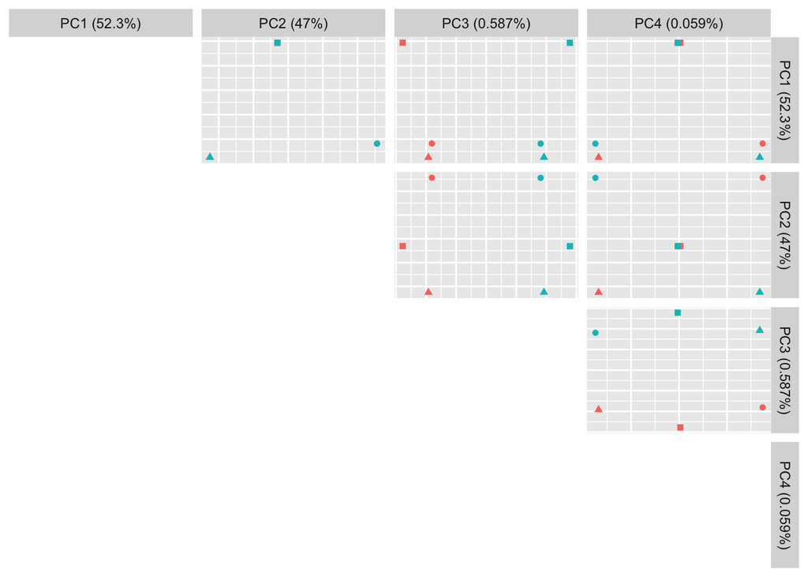

```r
x <- cbind(pca.run(rnaseq$count,rename = T),rnaseq$meta)
ggpairs(x,columns = 1:4,
        mapping = aes(color=factor(genome),shape=factor(sample.ID)),
        progress = F,
        lower  = list(continuous = "blank"),
        upper  = list(continuous = "points"),
        diag  = list(continuous = "blankDiag"))
```

PC3 is composed of contributions from the 1000 subsetted genes. The below plots show the percentage contributions of these genes w.r.t each of the principal components. We find that PC3 is dominated by a variation in a small set of genes, unlike PC1 and PC2, which vary instead across all genes.

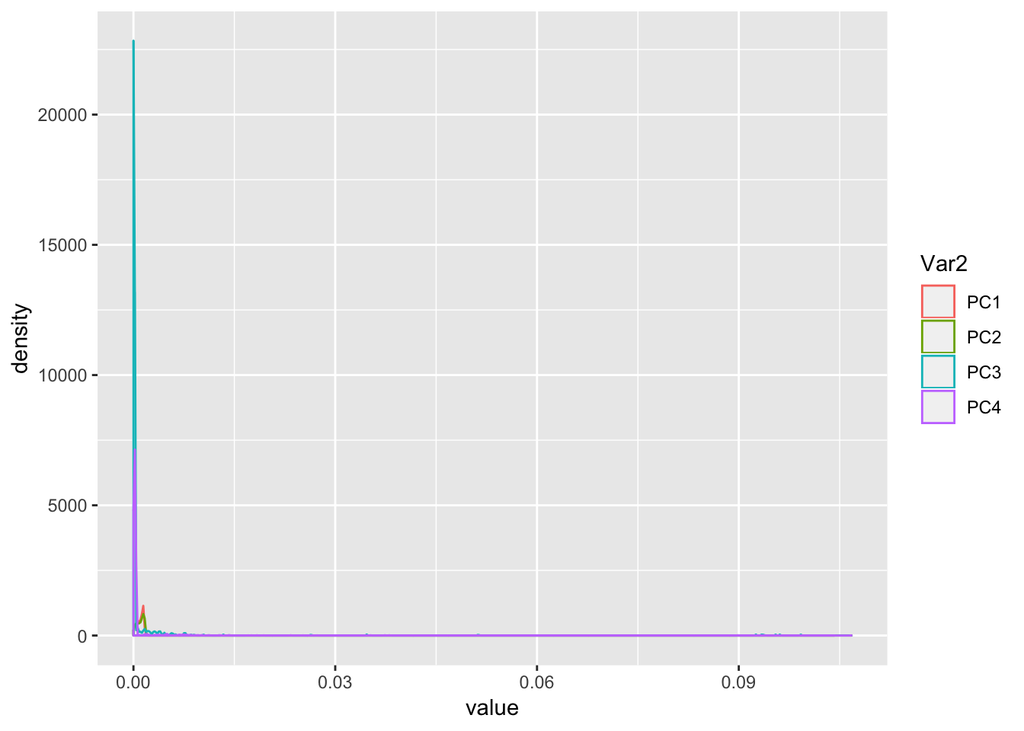

```r
x <- pca.prep(rnaseq$count,T,1000)
x <- prcomp(t(x),scale=T)
x <- abs(x$rotation)
x <- sweep(x,2,colSums(x),"/")
csx <- apply(x, 2, function(y) cumsum(sort(y,dec=T)))

ggplot(melt(x[,1:4])) + aes(x=value,colour=Var2) + geom_density()
```

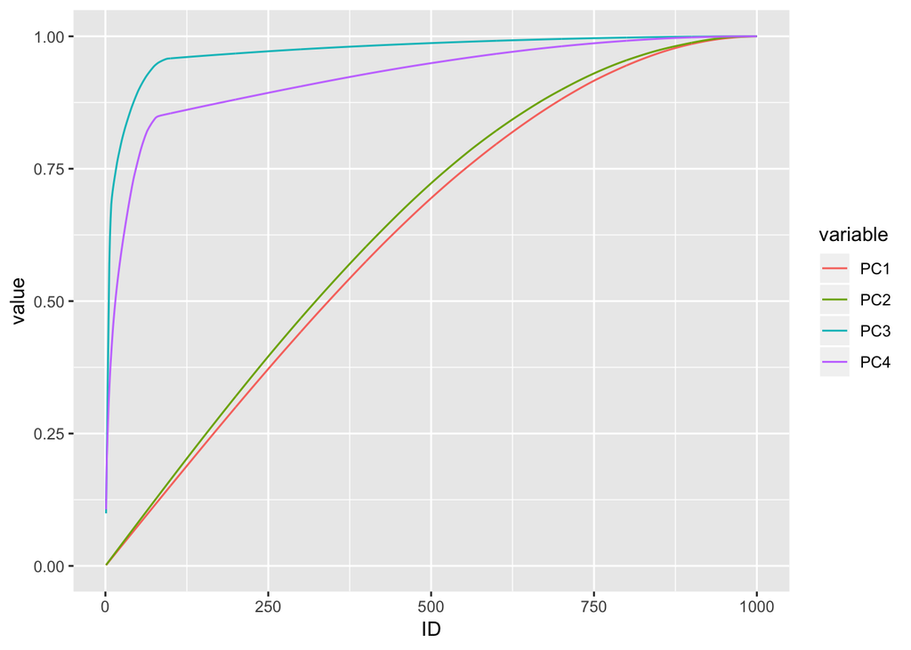

```r
ggplot(melt(data.frame(cbind(ID=1:nrow(x),csx[,1:4])),id.vars="ID")) + aes(x=ID,y=value,color=variable) + geom_line()
```

The below list gives all genes which contribute at least 1% to PC3

```r
top.genes <- x[which(x[,3]>0.01),3,drop=F]
if(nrow(top.genes)){
  top.genes <- data.table(top.genes,keep.rownames = "ENSEMBL")
  print(top.genes <- merge(
    top.genes,
    biomaRt::select(org.Hs.eg.db,keys=top.genes$ENSEMBL,keytype = "ENSEMBL",columns = c("ENSEMBL","ENTREZID","SYMBOL"))
    ,sort=F
  ))
}
```

```
##             ENSEMBL        PC3  ENTREZID SYMBOL
##  1: ENSG00000213235 0.09550559      <NA>   <NA>
##  2: ENSG00000259838 0.03468191      <NA>   <NA>
##  3: ENSG00000206625 0.09612784     26827 RNU6-1
##  4: ENSG00000206932 0.09255865      <NA>   <NA>
##  5: ENSG00000230291 0.01336079      <NA>   <NA>
##  6: ENSG00000207357 0.09924277 103625684 RNU6-2
##  7: ENSG00000207507 0.09368767 101954271 RNU6-9
##  8: ENSG00000227376 0.05126931      <NA>   <NA>
##  9: ENSG00000207041 0.09341737      <NA>   <NA>
## 10: ENSG00000218227 0.01038607      <NA>   <NA>
## 11: ENSG00000204894 0.02639326      <NA>   <NA>
```

```r
top.genes <- x[which(x[,4]>0.01),3,drop=F]
if(nrow(top.genes)){
  top.genes <- data.table(top.genes,keep.rownames = "ENSEMBL")
  print(top.genes <- merge(
    top.genes,
    biomaRt::select(org.Hs.eg.db,keys=top.genes$ENSEMBL,keytype = "ENSEMBL",columns = c("ENSEMBL","ENTREZID","SYMBOL"))
    ,sort=F
  ))
}
```

```
##             ENSEMBL         PC3  ENTREZID  SYMBOL
##  1: ENSG00000213235 0.095505585      <NA>    <NA>
##  2: ENSG00000259838 0.034681911      <NA>    <NA>
##  3: ENSG00000206625 0.096127843     26827  RNU6-1
##  4: ENSG00000266934 0.003020439      <NA>    <NA>
##  5: ENSG00000206932 0.092558646      <NA>    <NA>
##  6: ENSG00000207357 0.099242769 103625684  RNU6-2
##  7: ENSG00000213399 0.004153880      <NA>    <NA>
##  8: ENSG00000241889 0.003696046      <NA>    <NA>
##  9: ENSG00000207507 0.093687666 101954271  RNU6-9
## 10: ENSG00000220472 0.007783902      <NA>    <NA>
## 11: ENSG00000227376 0.051269311      <NA>    <NA>
## 12: ENSG00000218227 0.010386072      <NA>    <NA>
## 13: ENSG00000169059 0.003838262     51481   VCX3A
## 14: ENSG00000185863 0.002998480 100505993 TMEM210
## 15: ENSG00000234268 0.005010495      <NA>    <NA>
## 16: ENSG00000204894 0.026393256      <NA>    <NA>
## 17: ENSG00000231414 0.003330510      <NA>    <NA>
## 18: ENSG00000219451 0.005678936    222901 RPL23P8
## 19: ENSG00000267193 0.003260872      <NA>    <NA>
## 20: ENSG00000253899 0.004542773      <NA>    <NA>
```

# DE analysis

```r
genome <- factor(rnaseq$meta$genome)
d <- model.matrix(~0+genome)
colnames(d) <- gsub("genome","",colnames(d))

cont <- makeContrasts(
  b37.mmu10-b37,
  levels=colnames(d)
)

DE.data <- DE.run(rnaseq$count,d,cont.matrix = cont)
```

[figure not shown]

[figure not shown]

```r
for(i in 1:ncol(cont)){
  print(colnames(cont)[i])
  print(topTable.annotated.DE(DE.data$efit,coef=i))
}
```

```
## [1] "b37.mmu10 - b37"
```

```
## Empty data.table (0 rows) of 2 cols: rn,x
```